# Logistic_Courier_Service

```python
# !pip install matplotlib --upgrade
```

**Note:**

- Upgrade the matplotlib version form 3.2.2 to 3.5.3
  - Use command

    ```
    !pip install matplotlib --upgrade
    ```

- Restart the session

# Define Problem Statement and perform Exploratory Data Analysis

**About the Business**

This business case is about India's largest B2B & C2C Logistic Courier Service Provider in India. It is the largest and fastest-growing fully integrated player in India by revenue in Fiscal 2021. They aim to build the operating system for commerce, through a combination of world-class infrastructure, logistics operations of the highest quality, and cutting-edge engineering and technology capabilities.

The Data team builds intelligence and capabilities using this data that helps them to widen the gap between the quality, efficiency, and profitability of their business versus their competitors.

**Concept Used**

The company wants to understand and process the data coming out of data engineering pipelines:

- Clean, sanitize and manipulate data to get useful features out of raw fields
- Make sense out of the raw data and help the data science team to build forecasting models on it

**We will carry out the following steps (Concept Used):**

- Feature Creation
- Relationship between Features
- Column Normalization /Column Standardization
- Handling categorical values
- Missing values - Outlier treatment / Types of outliers

## Download the dataset and observe a subset of the data

**Importing Required Libraries**

```python
# !pip install matplotlib==3.5.3
import numpy as np
import pandas as pd
import matplotlib
import matplotlib.pyplot as plt
from matplotlib.ticker import (MultipleLocator, AutoMinorLocator)
import seaborn as sns
import textwrap
import math
import re
from sklearn.preprocessing import MinMaxScaler
from scipy import stats
```

```python
df = pd.read_csv('/content/Courier_data.csv')
pd.set_option('display.max_columns', None)
df.head(4)
```

|  | data | trip_creation_time | route_schedule_uuid | route_type | trip_uuid | source_center | source_name | destination_center | destination_name | od_start_time | od_end_time | start_scan_to_end_scan | is_cutoff | cutoff_factor | cutoff_timestamp | actual_distance_to_destination | actual_time | osrm_time | osrm_distance | factor | segment_actual_time | segment_osrm_time | segment_osrm_distance | segment_factor |
| --- | --- | --- | --- | --- | --- | --- | --- | --- | --- | --- | --- | --- | --- | --- | --- | --- | --- | --- | --- | --- | --- | --- | --- | --- |
| 0 | training | 2018-09-20 02:35:36.476840 | thanos::sroute:eb7bfc78-b351-4c0e-a951-fa3d5c3... | Carting | trip-153741093647649320 | IND388121AAA | Anand_VUNagar_DC (Gujarat) | IND388620AAB | Khambhat_MotvdDPP_D (Gujarat) | 2018-09-20 03:21:32.418600 | 2018-09-20 04:47:45.236797 | 86.0 | True | 9.0 | 2018-09-20 04:27:55 | 10.435660 | 14.0 | 11.0 | 11.9653 | 1.272727 | 14.0 | 11.0 | 11.9653 | 1.272727 |
| 1 | training | 2018-09-20 02:35:36.476840 | thanos::sroute:eb7bfc78-b351-4c0e-a951-fa3d5c3... | Carting | trip-153741093647649320 | IND388121AAA | Anand_VUNagar_DC (Gujarat) | IND388620AAB | Khambhat_MotvdDPP_D (Gujarat) | 2018-09-20 03:21:32.418600 | 2018-09-20 04:47:45.236797 | 86.0 | True | 18.0 | 2018-09-20 04:17:55 | 18.936842 | 24.0 | 20.0 | 21.7243 | 1.200000 | 10.0 | 9.0 | 9.7590 | 1.111111 |
| 2 | training | 2018-09-20 02:35:36.476840 | thanos::sroute:eb7bfc78-b351-4c0e-a951-fa3d5c3... | Carting | trip-153741093647649320 | IND388121AAA | Anand_VUNagar_DC (Gujarat) | IND388620AAB | Khambhat_MotvdDPP_D (Gujarat) | 2018-09-20 03:21:32.418600 | 2018-09-20 04:47:45.236797 | 86.0 | True | 27.0 | 2018-09-20 04:01:19.505586 | 27.637279 | 40.0 | 28.0 | 32.5395 | 1.428571 | 16.0 | 7.0 | 10.8152 | 2.285714 |
| 3 | training | 2018-09-20 02:35:36.476840 | thanos::sroute:eb7bfc78-b351-4c0e-a951-fa3d5c3... | Carting | trip-153741093647649320 | IND388121AAA | Anand_VUNagar_DC (Gujarat) | IND388620AAB | Khambhat_MotvdDPP_D (Gujarat) | 2018-09-20 03:21:32.418600 | 2018-09-20 04:47:45.236797 | 86.0 | True | 36.0 | 2018-09-20 03:39:57 | 36.118028 | 62.0 | 40.0 | 45.5620 | 1.550000 | 21.0 | 12.0 | 13.0224 | 1.750000 |

**Column Profiling**

- data - tells whether the data is testing or training data
- trip_creation_time – Timestamp of trip creation
- route_schedule_uuid – Unique Id for a particular route schedule
- route_type – Transportation type
  - FTL – Full Truck Load: FTL shipments get to the destination sooner, as the truck is making no other pickups or drop-offs along the way
  - Carting: Handling system consisting of small vehicles (carts)
- trip_uuid - Unique ID given to a particular trip (A trip may include different source and destination centers)
- source_center - Source ID of trip origin
- source_name - Source Name of trip origin
- destination_cente – Destination ID
- destination_name – Destination Name
- od_start_time – Trip start time
- od_end_time – Trip end time
- start_scan_to_end_scan – Time taken to deliver from source to destination
- is_cutoff – Unknown field
- cutoff_factor – Unknown field
- cutoff_timestamp – Unknown field
- actual_distance_to_destination – Distance in Kms between source and destination warehouse
- actual_time – Actual time taken to complete the delivery (Cumulative)
- osrm_time – An open-source routing engine time calculator which computes the shortest path between points in a given map (Includes usual traffic, distance through major and minor roads) and gives the time (Cumulative)
- osrm_distance – An open-source routing engine which computes the shortest path between points in a given map (Includes usual traffic, distance through major and minor roads) (Cumulative)
- factor – Unknown field
- segment_actual_time – This is a segment time. Time taken by the subset of the package delivery
- segment_osrm_time – This is the OSRM segment time. Time taken by the subset of the package delivery
- segment_osrm_distance – This is the OSRM distance. Distance covered by subset of the package delivery
- segment_factor – Unknown field

Custom function to get Discriptive Summary of the Dataset

```python
def get_df_summary(df_, print_summary=True, properties_as_columns=True):
  # Shape and memory usage of DataFrame
  print(f'RangeIndex: {df_.shape[0]} entries; Data columns (total {df_.shape[1]} columns)')
  memory_used = df_.memory_usage().sum()/1024
  if memory_used > 1024*1024:
    memory_used =  f'{round(memory_used/1024/1024, 1)}+ GB'
  elif memory_used > 1024:
    memory_used =  f'{round(memory_used/1024, 1)}+ MB'
  else:
    memory_used =  f'{round(memory_used, 1)}+ KB'
  print(f'memory usage: {memory_used}\n')

  # Create an empty df with column names from original df
  df2 = pd.DataFrame(columns=[None]+df_.columns.to_list())

  # Add dtype
  property_ = ['dtype']
  for clm in df_.columns:
    property_.append(df_[clm].dtype)
  df2 = df2.append(pd.DataFrame([property_], columns=df2.columns))

  # Add Missing Values Counts
  property_ = ['Missing Counts']
  for clm in df_.columns:
    property_.append(df_[clm].isna().sum())
  df2 = df2.append(pd.DataFrame([property_], columns=df2.columns))

  # Add nUniques
  property_ = ['nUniques']
  for clm in df_.columns:
    property_.append(df_[clm].nunique())
  df2 = df2.append(pd.DataFrame([property_], columns=df2.columns))

  # Add unique values
  # top 10
  property_ = ['Top 10 Unique Values']
  for clm in df_.columns:
    df1 = df_[clm].value_counts().reset_index()
    df1['margin'] = df1[clm]*100/ df1[clm].sum()
    property_.append(', '.join([i for i in df1.apply(lambda x:f"{x['index']} ({math.floor(x['margin'])}%)", axis=1).iloc[:10]]))
  df2 = df2.append(pd.DataFrame([property_], columns=df2.columns))

  # Add unique values
  # bottom 10
  property_ = ['Bottom 10 Unique Values']
  for clm in df_.columns:
    df1 = df_[clm].value_counts().reset_index()
    df1['margin'] = df1[clm]*100/ df1[clm].sum()
    property_.append(', '.join([i for i in df1.apply(lambda x:f"{x['index']} ({math.floor(x['margin'])}%)", axis=1).iloc[-1:-11:-1]]))
  df2 = df2.append(pd.DataFrame([property_], columns=df2.columns))

  # Getting Numeric Variables Statistics
  df4 = pd.DataFrame(columns=df_.columns.to_list())
  df4 = df4.append(df_.describe()).drop('count').rename({
      '25%': 'Q1',
      '50%': 'Median',
      '75%': 'Q3'
  }).reset_index().set_index('index').round(1)
  df4 = df4.T
  df4['LW (1.5)'] = df4.apply(lambda x: max(x['min'], x['Q1'] - 1.5*(x['Q3']-x['Q1'])), axis=1)
  df4['UW (1.5)'] = df4.apply(lambda x: min(x['max'], x['Q3'] + 1.5*(x['Q3']-x['Q1'])), axis=1)

  df4['mean-3*std'] = df4.apply(lambda x: max(x['min'], x['mean'] - 3*x['std']), axis=1)
  df4['mean+3*std'] = df4.apply(lambda x: min(x['max'], x['mean'] + 3*x['std']), axis=1)

  lst_IQR_Outlier = []
  lst_std_Outlier = []
  for clm in df4.index:
    if clm in df_.describe().columns:
      iqr_outlier_count = df_.loc[(df_[clm]<df4.loc[clm,'LW (1.5)']) | (df_[clm]>df4.loc[clm,'UW (1.5)'])].shape[0]
      iqr_outlier_pct = f'({round(iqr_outlier_count * 100.0 / df_.__len__(), 1)}%)' if iqr_outlier_count != 0 else ''

      std_outlier_count = df_.loc[(df_[clm]<df4.loc[clm,'mean-3*std']) | (df_[clm]>df4.loc[clm,'mean+3*std'])].shape[0]
      std_outlier_pct = f'({round(std_outlier_count * 100.0 / df_.__len__(), 1)}%)' if std_outlier_count != 0 else ''

      lst_IQR_Outlier.append(f'{iqr_outlier_count} {iqr_outlier_pct}')
      lst_std_Outlier.append(f'{std_outlier_count} {std_outlier_pct}')
    else:
      lst_IQR_Outlier.append(np.nan)
      lst_std_Outlier.append(np.nan)

  df4['Outlier Count (1.5*IQR)'] = lst_IQR_Outlier
  df4['Outlier Count (3*std)'] = lst_std_Outlier

  df4 = df4.round(1).T.reset_index().rename({'index': None}, axis=1)
  df2 = df2.append(df4)

  # Sort the columns acording to dtype
  df2 = df2.set_index(None).T.astype(str).sort_values('dtype', ascending=False)
  df2 = df2[['dtype', 'Missing Counts', 'nUniques',
             'Top 10 Unique Values', 'Bottom 10 Unique Values', 'min','max',
  'LW (1.5)', 'Q1', 'Median', 'Q3',   'UW (1.5)', 'Outlier Count (1.5*IQR)',
  'mean-3*std',  'mean', 'std', 'mean+3*std', 'Outlier Count (3*std)']]

  if not properties_as_columns: df2 = df2.T
  if print_summary: print(df2)

  return df2
```

**Descriptive Summary**

- Observe shape of the data, the data types of all attributes
- Missing value detection, outlier checking, statistical summarization

```python
df_summary = get_df_summary(df, print_summary=False, properties_as_columns=False)
df_summary
```

```
RangeIndex: 144867 entries; Data columns (total 24 columns)
memory usage: 25.6+ MB
```

|  | data | destination_center | cutoff_timestamp | trip_creation_time | od_end_time | destination_name | od_start_time | source_name | source_center | trip_uuid | route_type | route_schedule_uuid | cutoff_factor | osrm_distance | segment_osrm_distance | segment_osrm_time | segment_actual_time | factor | segment_factor | osrm_time | actual_time | actual_distance_to_destination | start_scan_to_end_scan | is_cutoff |
| --- | --- | --- | --- | --- | --- | --- | --- | --- | --- | --- | --- | --- | --- | --- | --- | --- | --- | --- | --- | --- | --- | --- | --- | --- |
| dtype | object | object | object | object | object | object | object | object | object | object | object | object | int64 | float64 | float64 | float64 | float64 | float64 | float64 | float64 | float64 | float64 | float64 | bool |
| Missing Counts | 0 | 0 | 0 | 0 | 0 | 261 | 0 | 293 | 0 | 0 | 0 | 0 | 0 | 0 | 0 | 0 | 0 | 0 | 0 | 0 | 0 | 0 | 0 | 0 |
| nUniques | 2 | 1481 | 93180 | 14817 | 26369 | 1468 | 26369 | 1498 | 1508 | 14817 | 2 | 1504 | 501 | 138046 | 113799 | 214 | 747 | 45641 | 5675 | 1531 | 3182 | 144515 | 1915 | 2 |
| Top 10 Unique Values | training (72%), test (27%) | IND000000ACB (10%), IND562132AAA (7%), IND4213... | 2018-09-24 05:19:20 (0%), 2018-09-24 05:19:21 ... | 2018-09-28 05:23:15.359220 (0%), 2018-10-02 06... | 2018-09-24 09:59:15.691618 (0%), 2018-10-05 11... | Gurgaon_Bilaspur_HB (Haryana) (10%), Bangalore... | 2018-09-21 18:37:09.322207 (0%), 2018-10-03 04... | Gurgaon_Bilaspur_HB (Haryana) (16%), Bangalore... | IND000000ACB (16%), IND562132AAA (6%), IND4213... | trip-153811219535896559 (0%), trip-15384603530... | FTL (68%), Carting (31%) | thanos::sroute:4029a8a2-6c74-4b7e-a6d8-f9e069f... | 22.0 (9%), 9.0 (8%), 44.0 (5%), 18.0 (5%), 66.... | 48.0394 (0%), 11.23 (0%), 11.3233 (0%), 12.541... | 0.0 (1%), 25.6081 (0%), 22.6267 (0%), 58.2708 ... | 16.0 (7%), 17.0 (7%), 18.0 (6%), 19.0 (4%), 15... | 24.0 (4%), 26.0 (3%), 30.0 (3%), 27.0 (3%), 23... | 2.0 (1%), 1.5 (0%), 1.6666666666666667 (0%), 1... | 2.0 (4%), 1.5 (3%), 1.0 (1%), 1.66666666666666... | 21.0 (1%), 20.0 (1%), 18.0 (1%), 22.0 (1%), 17... | 32.0 (0%), 36.0 (0%), 30.0 (0%), 38.0 (0%), 42... | 100.28289202009655 (0%), 19.122553143991365 (0... | 110.0 (0%), 72.0 (0%), 99.0 (0%), 95.0 (0%), 8... | True (81%), False (18%) |
| Bottom 10 Unique Values | test (27%), training (72%) | IND504215AAA (0%), IND110046AAA (0%), IND40070... | 2018-09-20 16:24:28.436231 (0%), 2018-09-26 05... | 2018-09-14 17:04:32.989471 (0%), 2018-09-19 04... | 2018-09-27 15:47:50.386008 (0%), 2018-09-20 04... | Basta_Central_DPP_1 (Orissa) (0%), Mumbai_Sanp... | 2018-09-27 02:59:59.877566 (0%), 2018-09-20 02... | Faridabad_Old (Haryana) (0%), Krishnanagar_Ana... | IND741101AAB (0%), IND222001AAA (0%), IND24200... | trip-153694467298919626 (0%), trip-15373317447... | Carting (31%), FTL (68%) | thanos::sroute:404cbabf-d2a5-4e46-bf79-8b3c518... | 275.0 (0%), 412.0 (0%), 1149.0 (0%), 734.0 (0%... | 88.7319 (0%), 307.6147 (0%), 28.7254 (0%), 55.... | 8.8088 (0%), 10.8209 (0%), 8.1647 (0%), 0.7952... | 1032.0 (0%), 156.0 (0%), 204.0 (0%), 163.0 (0%... | 1104.0 (0%), 1847.0 (0%), 540.0 (0%), 517.0 (0... | 4.484210526315789 (0%), 1.9186746987951808 (0%... | 29.77777777777778 (0%), 2.6144578313253013 (0%... | 1312.0 (0%), 1250.0 (0%), 1130.0 (0%), 1614.0 ... | 2980.0 (0%), 2870.0 (0%), 2910.0 (0%), 2608.0 ... | 70.03901016351531 (0%), 9.162212958326531 (0%)... | 2706.0 (0%), 3361.0 (0%), 905.0 (0%), 22.0 (0%... | False (18%), True (81%) |
| min | nan | nan | nan | nan | nan | nan | nan | nan | nan | nan | nan | nan | 9.0 | 9.0 | 0.0 | 0.0 | -244.0 | 0.1 | -23.4 | 6.0 | 9.0 | 9.0 | 20.0 | nan |
| max | nan | nan | nan | nan | nan | nan | nan | nan | nan | nan | nan | nan | 1927.0 | 2326.2 | 2191.4 | 1611.0 | 3051.0 | 77.4 | 574.2 | 1686.0 | 4532.0 | 1927.4 | 7898.0 | nan |
| LW (1.5) | nan | nan | nan | nan | nan | nan | nan | nan | nan | nan | nan | nan | 9.0 | 9.0 | 0.0 | 0.0 | -10.0 | 0.7 | -0.1 | 6.0 | 9.0 | 9.0 | 20.0 | nan |
| Q1 | nan | nan | nan | nan | nan | nan | nan | nan | nan | nan | nan | nan | 22.0 | 29.9 | 12.1 | 11.0 | 20.0 | 1.6 | 1.3 | 27.0 | 51.0 | 23.4 | 161.0 | nan |
| Median | nan | nan | nan | nan | nan | nan | nan | nan | nan | nan | nan | nan | 66.0 | 78.5 | 23.5 | 17.0 | 29.0 | 1.9 | 1.7 | 64.0 | 132.0 | 66.1 | 449.0 | nan |
| Q3 | nan | nan | nan | nan | nan | nan | nan | nan | nan | nan | nan | nan | 286.0 | 343.2 | 27.8 | 22.0 | 40.0 | 2.2 | 2.2 | 257.0 | 513.0 | 286.7 | 1634.0 | nan |
| UW (1.5) | nan | nan | nan | nan | nan | nan | nan | nan | nan | nan | nan | nan | 682.0 | 813.2 | 51.4 | 38.5 | 70.0 | 3.1 | 3.6 | 602.0 | 1206.0 | 681.7 | 3843.5 | nan |
| Outlier Count (1.5*IQR) | nan | nan | nan | nan | nan | nan | nan | nan | nan | nan | nan | nan | 17246 (11.9%) | 17811 (12.3%) | 4328 (3.0%) | 6378 (4.4%) | 9298 (6.4%) | 11769 (8.1%) | 14416 (10.0%) | 17603 (12.2%) | 16633 (11.5%) | 17992 (12.4%) | 373 (0.3%) | nan |
| mean-3*std | nan | nan | nan | nan | nan | nan | nan | nan | nan | nan | nan | nan | 9.0 | 9.0 | 0.0 | 0.0 | -124.6 | 0.1 | -12.2 | 6.0 | 9.0 | 9.0 | 20.0 | nan |
| mean | nan | nan | nan | nan | nan | nan | nan | nan | nan | nan | nan | nan | 232.9 | 284.8 | 22.8 | 18.5 | 36.2 | 2.1 | 2.2 | 213.9 | 416.9 | 234.1 | 961.3 | nan |
| std | nan | nan | nan | nan | nan | nan | nan | nan | nan | nan | nan | nan | 344.8 | 421.1 | 17.9 | 14.8 | 53.6 | 1.7 | 4.8 | 308.0 | 598.1 | 345.0 | 1037.0 | nan |
| mean+3*std | nan | nan | nan | nan | nan | nan | nan | nan | nan | nan | nan | nan | 1267.3 | 1548.1 | 76.5 | 62.9 | 197.0 | 7.2 | 16.6 | 1137.9 | 2211.2 | 1269.1 | 4072.3 | nan |
| Outlier Count (3*std) | nan | nan | nan | nan | nan | nan | nan | nan | nan | nan | nan | nan | 3428 (2.4%) | 3611 (2.5%) | 1504 (1.0%) | 2113 (1.5%) | 1201 (0.8%) | 1348 (0.9%) | 806 (0.6%) | 3595 (2.5%) | 3526 (2.4%) | 3429 (2.4%) | 350 (0.2%) | nan |

Drop Unknown Fields

```python
df = df.drop(['is_cutoff', 'cutoff_factor', 'cutoff_timestamp', 'factor', 'segment_factor'], axis=1)
```

Fill missing values in "source_name" and "destination_name" fields

```python
df['source_name'].fillna('Unknown', inplace=True)
df['destination_name'].fillna('Unknown', inplace=True)
```

Create OD Time Diff field and drop OD Start and End Time Fields

```python
df['od_start_time'] = pd.to_datetime(df['od_start_time'], errors='coerce')
df['od_end_time'] = pd.to_datetime(df['od_end_time'], errors='coerce')

df['od_time_diff_mins'] = (df['od_end_time'] - df['od_start_time']).dt.total_seconds()/60

df = df.drop(['od_start_time', 'od_end_time'], axis=1)
```

Group the rows for each 'trip_uuid' using aggregation

```python
create_trip_dict = {
    'data' : 'first',
    'trip_creation_time' : 'first',
    'route_schedule_uuid': 'first',
    'route_type': 'first',
    'trip_uuid': 'first',

    'source_center': 'first',
    'source_name': 'first',

    'destination_center': 'last',
    'destination_name': 'last',

    'od_time_diff_mins' : 'sum',
    'start_scan_to_end_scan': 'sum',

    'actual_distance_to_destination': 'sum',
    'actual_time': 'sum',
    'osrm_time': 'sum',
    'osrm_distance': 'sum',

    'segment_actual_time': 'sum',
    'segment_osrm_time': 'sum',
    'segment_osrm_distance': 'sum'
}

df = df.groupby('trip_uuid').agg(create_trip_dict).reset_index(drop=True)
```

Split the Source and Destination name to create separate features for City, Place and State

Drop Source Name and Destination Name fields

```python
def city_place_state_separator(text):
  result = re.search('(^[A-Za-z]+)[_|\s](.+)(\(.+\))', text)

  if result:
    city = result.group(1)
    place = result.group(2).rstrip().lstrip().replace('_', ' ')
    state = result.group(3)[1:-1]

    return pd.Series([city, place, state])

  else:
    return pd.Series([text, text, text])
```

```python
df[['source_city', 'source_place', 'source_state']] = df['source_name'].apply(city_place_state_separator)
df[['destination_city', 'destination_place', 'destination_state']] = df['destination_name'].apply(city_place_state_separator)
df = df.drop(['source_name', 'destination_name'], axis=1)
```

Extract Trip Creation month, year and day from Trip Creation Time field

Drop the Trip_creation_time feature

```python
def timestapm_to_year_month_day(ts):
  return pd.Series([pd.to_datetime(ts).year, pd.to_datetime(ts).month, pd.to_datetime(ts).day])

df[['trip_creation_year', 'trip_creation_month', 'trip_creation_day']] = df['trip_creation_time'].apply(timestapm_to_year_month_day)
df = df.drop('trip_creation_time', axis=1)
```

Outlier Treatment:

Since there is huge difference between median and mean; and as observed in dataframe summary, there are extreem outliers

We will remove the outliers using IQR method

```python
df = df[(df['segment_osrm_distance'] > float(df_summary.loc['LW (1.5)', 'segment_osrm_distance'])) & (df['segment_osrm_distance'] < float(df_summary.loc['UW (1.5)', 'segment_osrm_distance']))]
df = df[(df['segment_osrm_time'] > float(df_summary.loc['LW (1.5)', 'segment_osrm_time'])) & (df['segment_osrm_time'] < float(df_summary.loc['UW (1.5)', 'segment_osrm_time']))]
df = df[(df['osrm_distance'] > float(df_summary.loc['LW (1.5)', 'osrm_distance'])) & (df['osrm_distance'] < float(df_summary.loc['UW (1.5)', 'osrm_distance']))]
df = df[(df['osrm_time'] > float(df_summary.loc['LW (1.5)', 'osrm_time'])) & (df['osrm_time'] < float(df_summary.loc['UW (1.5)', 'osrm_time']))]
df = df[(df['actual_time'] > float(df_summary.loc['LW (1.5)', 'actual_time'])) & (df['actual_time'] < float(df_summary.loc['UW (1.5)', 'actual_time']))]
df = df[(df['actual_distance_to_destination'] > float(df_summary.loc['LW (1.5)', 'actual_distance_to_destination'])) & (df['actual_distance_to_destination'] < float(df_summary.loc['UW (1.5)', 'actual_distance_to_destination']))]
df = df[(df['start_scan_to_end_scan'] > float(df_summary.loc['LW (1.5)', 'start_scan_to_end_scan'])) & (df['start_scan_to_end_scan'] < float(df_summary.loc['UW (1.5)', 'start_scan_to_end_scan']))]
df = df[(df['od_time_diff_mins'] > float(df_summary.loc['LW (1.5)', 'od_time_diff_mins'])) & (df['od_time_diff_mins'] < float(df_summary.loc['UW (1.5)', 'od_time_diff_mins']))]
df = df[(df['segment_actual_time'] > float(df_summary.loc['LW (1.5)', 'segment_actual_time'])) & (df['segment_actual_time'] < float(df_summary.loc['UW (1.5)', 'segment_actual_time']))]
```

Normalize the numerical featuers

```python
df_num_cols = df[['segment_osrm_distance', 'segment_osrm_time', 'osrm_distance', 'osrm_time', 'actual_time', 'actual_distance_to_destination', 'start_scan_to_end_scan', 'od_time_diff_mins', 'segment_actual_time']]
df_num_cols = pd.DataFrame(MinMaxScaler().fit_transform(df_num_cols), columns = df_num_cols.columns)
```

Perform one-hot encoding of categorical variable "route_type"

```python
df = pd.concat((df, pd.get_dummies(df['route_type'], prefix = 'route_type')), axis=1)
df = df.drop('route_type', axis = 1)
```

Convert the 'Data' feature to categorical data type

```python
df['data'] = df['data'].astype('category')
```

Summary of dataframe after the preprocessing operations

```python
get_df_summary(df, print_summary=False, properties_as_columns=False)
```

```
RangeIndex: 12219 entries; Data columns (total 25 columns)
memory usage: 2.2+ MB
```

|  | route_type_FTL | route_type_Carting | source_place | trip_uuid | source_center | destination_center | destination_state | destination_place | destination_city | route_schedule_uuid | source_state | source_city | trip_creation_day | trip_creation_month | trip_creation_year | segment_osrm_time | segment_osrm_distance | segment_actual_time | osrm_distance | osrm_time | actual_time | actual_distance_to_destination | start_scan_to_end_scan | od_time_diff_mins | data |
| --- | --- | --- | --- | --- | --- | --- | --- | --- | --- | --- | --- | --- | --- | --- | --- | --- | --- | --- | --- | --- | --- | --- | --- | --- | --- |
| dtype | uint8 | uint8 | object | object | object | object | object | object | object | object | object | object | int64 | int64 | int64 | float64 | float64 | float64 | float64 | float64 | float64 | float64 | float64 | float64 | category |
| Missing Counts | 0 | 0 | 0 | 0 | 0 | 0 | 0 | 0 | 0 | 0 | 0 | 0 | 0 | 0 | 0 | 0 | 0 | 0 | 0 | 0 | 0 | 0 | 0 | 0 | 0 |
| nUniques | 2 | 2 | 684 | 12219 | 823 | 928 | 59 | 784 | 746 | 1316 | 52 | 640 | 22 | 2 | 1 | 373 | 12156 | 715 | 12193 | 932 | 1687 | 12208 | 3062 | 12219 | 2 |
| Top 10 Unique Values | 0.0 (71%), 1.0 (28%) | 1.0 (71%), 0.0 (28%) | Bilaspur HB (5%), Mankoli HB (5%), Hub (4%), N... | trip-153671042288605164 (0%), trip-15379207477... | IND000000ACB (5%), IND421302AAG (5%), IND56213... | IND000000ACB (4%), IND421302AAG (3%), IND56213... | Maharashtra (18%), Karnataka (16%), Haryana (1... | Bilaspur HB (4%), Hub (3%), Mankoli HB (3%), N... | Mumbai (9%), Bengaluru (8%), Gurgaon (4%), Del... | thanos::sroute:a16bfa03-3462-4bce-9c82-5784c7d... | Maharashtra (18%), Karnataka (16%), Haryana (1... | Bengaluru (8%), Mumbai (7%), Gurgaon (5%), Bhi... | 18.0 (5%), 15.0 (5%), 13.0 (5%), 12.0 (4%), 14... | 9.0 (87%), 10.0 (12%) | 2018.0 (100%) | 17.0 (1%), 20.0 (1%), 19.0 (1%), 18.0 (1%), 22... | 27.599800000000002 (0%), 54.7183 (0%), 31.6824... | 47.0 (0%), 41.0 (0%), 60.0 (0%), 35.0 (0%), 55... | 76.5141 (0%), 20.8553 (0%), 33.3202 (0%), 25.4... | 26.0 (1%), 30.0 (1%), 24.0 (1%), 27.0 (1%), 28... | 120.0 (0%), 68.0 (0%), 66.0 (0%), 78.0 (0%), 5... | 52.93246696402012 (0%), 27.080239836318736 (0%... | 396.0 (0%), 444.0 (0%), 300.0 (0%), 270.0 (0%)... | 913.1740793 (0%), 2420.9706173833333 (0%), 252... | training (71%), test (28%) |
| min | 0.0 | 0.0 | nan | nan | nan | nan | nan | nan | nan | nan | nan | nan | 1.0 | 9.0 | 2018.0 | 7.0 | 9.1 | 10.0 | 9.3 | 7.0 | 10.0 | 9.0 | 27.0 | 27.6 | nan |
| max | 1.0 | 1.0 | nan | nan | nan | nan | nan | nan | nan | nan | nan | nan | 30.0 | 10.0 | 2018.0 | 411.0 | 491.7 | 818.0 | 1390.7 | 1194.0 | 2444.0 | 1083.0 | 6436.0 | 6441.9 | nan |
| LW (1.5) | 0.0 | 0.0 | nan | nan | nan | nan | nan | nan | nan | nan | nan | nan | 1.0 | 9.0 | 2018.0 | 7.0 | 9.1 | 10.0 | 9.3 | 7.0 | 10.0 | 9.0 | 27.0 | 27.6 | nan |
| Q1 | 0.0 | 0.0 | nan | nan | nan | nan | nan | nan | nan | nan | nan | nan | 14.0 | 9.0 | 2018.0 | 27.0 | 29.0 | 59.0 | 60.4 | 53.0 | 122.0 | 47.2 | 348.0 | 350.6 | nan |
| Median | 0.0 | 1.0 | nan | nan | nan | nan | nan | nan | nan | nan | nan | nan | 19.0 | 9.0 | 2018.0 | 51.0 | 51.9 | 107.0 | 119.4 | 113.0 | 251.0 | 90.7 | 720.0 | 724.4 | nan |
| Q3 | 1.0 | 1.0 | nan | nan | nan | nan | nan | nan | nan | nan | nan | nan | 25.0 | 9.0 | 2018.0 | 113.5 | 130.1 | 228.0 | 315.1 | 282.0 | 574.0 | 254.3 | 1512.0 | 1514.4 | nan |
| UW (1.5) | 1.0 | 1.0 | nan | nan | nan | nan | nan | nan | nan | nan | nan | nan | 30.0 | 9.0 | 2018.0 | 243.2 | 281.8 | 481.5 | 697.2 | 625.5 | 1252.0 | 565.0 | 3258.0 | 3260.1 | nan |
| Outlier Count (1.5*IQR) | 0 | 0 | nan | nan | nan | nan | nan | nan | nan | nan | nan | nan | 0 | 1507 (12.3%) | 0 | 521 (4.3%) | 519 (4.2%) | 571 (4.7%) | 914 (7.5%) | 708 (5.8%) | 739 (6.0%) | 891 (7.3%) | 853 (7.0%) | 854 (7.0%) | nan |
| mean-3*std | 0.0 | 0.0 | nan | nan | nan | nan | nan | nan | nan | nan | nan | nan | 1.0 | 9.0 | 2018.0 | 7.0 | 9.1 | 10.0 | 9.3 | 7.0 | 10.0 | 9.0 | 27.0 | 27.6 | nan |
| mean | 0.3 | 0.7 | nan | nan | nan | nan | nan | nan | nan | nan | nan | nan | 18.4 | 9.1 | 2018.0 | 79.7 | 89.4 | 163.6 | 234.1 | 202.4 | 416.9 | 185.5 | 1141.5 | 1144.2 | nan |
| std | 0.5 | 0.5 | nan | nan | nan | nan | nan | nan | nan | nan | nan | nan | 8.0 | 0.3 | 0.0 | 73.5 | 84.9 | 145.4 | 258.2 | 210.9 | 420.6 | 210.3 | 1135.8 | 1137.3 | nan |
| mean+3*std | 1.0 | 1.0 | nan | nan | nan | nan | nan | nan | nan | nan | nan | nan | 30.0 | 10.0 | 2018.0 | 300.2 | 344.1 | 599.8 | 1008.7 | 835.1 | 1678.7 | 816.4 | 4548.9 | 4556.1 | nan |
| Outlier Count (3*std) | 0 | 0 | nan | nan | nan | nan | nan | nan | nan | nan | nan | nan | 0 | 0 | 0 | 198 (1.6%) | 169 (1.4%) | 224 (1.8%) | 296 (2.4%) | 186 (1.5%) | 222 (1.8%) | 281 (2.3%) | 235 (1.9%) | 235 (1.9%) | nan |

```python
df.head(4)
```

|  | data | route_schedule_uuid | trip_uuid | source_center | destination_center | od_time_diff_mins | start_scan_to_end_scan | actual_distance_to_destination | actual_time | osrm_time | osrm_distance | segment_actual_time | segment_osrm_time | segment_osrm_distance | source_city | source_place | source_state | destination_city | destination_place | destination_state | trip_creation_year | trip_creation_month | trip_creation_day | route_type_Carting | route_type_FTL |
| --- | --- | --- | --- | --- | --- | --- | --- | --- | --- | --- | --- | --- | --- | --- | --- | --- | --- | --- | --- | --- | --- | --- | --- | --- | --- |
| 1 | training | thanos::sroute:3a1b0ab2-bb0b-4c53-8c59-eb2a2c0... | trip-153671042288605164 | IND572101AAA | IND562101AAA | 913.174079 | 906.0 | 240.208306 | 399.0 | 210.0 | 269.4308 | 141.0 | 65.0 | 84.1894 | Tumkur | Veersagr I | Karnataka | Chikblapur | ShntiSgr D | Karnataka | 2018 | 9 | 12 | 1 | 0 |
| 3 | training | thanos::sroute:f0176492-a679-4597-8332-bbd1c7f... | trip-153671046011330457 | IND400072AAB | IND401104AAA | 200.989870 | 200.0 | 28.529648 | 82.0 | 24.0 | 31.6475 | 59.0 | 16.0 | 19.8766 | Mumbai | Hub | Maharashtra | Mumbai | MiraRd IP | Maharashtra | 2018 | 9 | 12 | 1 | 0 |
| 4 | training | thanos::sroute:d9f07b12-65e0-4f3b-bec8-df06134... | trip-153671052974046625 | IND583101AAA | IND583101AAA | 1588.710998 | 1586.0 | 239.007304 | 556.0 | 207.0 | 266.2914 | 340.0 | 115.0 | 146.7919 | Bellary | Dc | Karnataka | Bellary | Dc | Karnataka | 2018 | 9 | 12 | 0 | 1 |
| 5 | training | thanos::sroute:9bf03170-d0a2-4a3f-aa4d-9aaab3d... | trip-153671055416136166 | IND600116AAB | IND602105AAB | 251.365798 | 249.0 | 34.407865 | 92.0 | 30.0 | 38.1953 | 60.0 | 23.0 | 28.0647 | Chennai | Porur DPC | Tamil Nadu | Chennai | Sriperumbudur Dc | Tamil Nadu | 2018 | 9 | 12 | 1 | 0 |

# Custom functions to plot custom charts and tables

```python
def plot_hist_custom(ax_, df_, var_, title_, scale_x_major, scale_x_minor, color_='#DC3535'):
  if pd.api.types.is_datetime64_any_dtype(df_[var_]):
    df_[var_] = df_[var_].dt.year

  m1 = df_[var_].mean()
  st1 = df_[var_].std()

  q1 = df_[var_].quantile(.25)
  q2 = df_[var_].median()
  q3 = df_[var_].quantile(.75)

  sns.histplot(data=df_, x=var_, kde=True,
               binwidth=scale_x_minor,
               color=color_, ax=ax_, linewidth=2)
  df_mean = pd.DataFrame({'x': [m1, m1], 'y': ax_.get_ybound()})
  df_q1 = pd.DataFrame({'x': [q1, q1], 'y': ax_.get_ybound()})
  df_q2 = pd.DataFrame({'x': [q2, q2], 'y': ax_.get_ybound()})
  df_q3 = pd.DataFrame({'x': [q3, q3], 'y': ax_.get_ybound()})
  sns.lineplot(data=df_mean, x='x', y='y', color='red', ax=ax_, linestyle='--',
              estimator=None, linewidth = 2)
  sns.lineplot(data=df_q1, x='x', y='y', color='black', ax=ax_, linestyle='--',
              estimator=None, linewidth = 1)
  sns.lineplot(data=df_q2, x='x', y='y', color='cyan', ax=ax_, linestyle='--',
              estimator=None, linewidth = 2)
  sns.lineplot(data=df_q3, x='x', y='y', color='black', ax=ax_, linestyle='--',
              estimator=None, linewidth = 1)

  plt.sca(ax_)
  plt.title(title_, size=16, color='grey')
  plt.tick_params(
        axis='x',          # changes apply to the x-axis
        which='both',      # both major and minor ticks are affected
        bottom=False,      # ticks along the bottom edge are off
        top=False,         # ticks along the top edge are off
        labelbottom=False) # labels along the bottom edge are off
  plt.xlabel('')
  plt.ylabel('Count', size=12)
  plt.yticks(size=12)
  sns.despine(bottom=True, left=False, trim=True, ax=ax_)
  ax_.spines['left'].set_color('grey')

  ax_.xaxis.set_major_locator(MultipleLocator(scale_x_major))
  ax_.xaxis.set_major_formatter('{x:.0f}')
  ax_.xaxis.set_minor_locator(MultipleLocator(scale_x_minor))

  ax_.figure.set_size_inches(16,11)
  plt.subplots_adjust(top=0.95, right=0.869, hspace=0, wspace=0.1)

  return plt
```

```python
def plot_box_custom(ax_, df_, var_, xlabel_, scale_x_major, scale_x_minor, color_='#DC3535'):
  if pd.api.types.is_datetime64_any_dtype(df_[var_]):
    df_[var_] = df_[var_].dt.year

  m1 = df_[var_].mean()
  st1 = df_[var_].std()

  q1 = df_[var_].quantile(.25)
  q2 = df_[var_].median()
  q3 = df_[var_].quantile(.75)

  df_mean = pd.DataFrame({'x': [m1, m1], 'y': ax_.get_ybound()})
  df_q1 = pd.DataFrame({'x': [q1, q1], 'y': ax_.get_ybound()})
  df_q2 = pd.DataFrame({'x': [q2, q2], 'y': ax_.get_ybound()})
  df_q3 = pd.DataFrame({'x': [q3, q3], 'y': ax_.get_ybound()})

  df_mean['y'] = [-0.3, 0.2]
  df_q1['y'] = [0.2, 0.25]
  df_q2['y'] = [0.1, 0.25]
  df_q3['y'] = [0.2, 0.25]

  sns.boxplot(data=df_, x=var_, ax=ax_,
                    color=color_, showmeans=True,
                    flierprops={"marker": "x"}, medianprops={"color": "cyan"},
                    width=0.4, fliersize=1, linewidth=2, notch=True)
  sns.lineplot(data=df_mean, x='x', y='y', color='red', ax=ax_, linestyle='--',
              estimator=None, linewidth = 2)
  text = f' μ={m1:.1f}\n σ={st1:.1f}'
  ax_.annotate(text, xy=(m1, -0.3), rotation=90)

  sns.lineplot(data=df_q1, x='x', y='y', color='black', ax=ax_, linestyle='--',
              estimator=None, linewidth = 1)
  text = f'Q1={q1:.1f} '
  ax_.annotate(text, xy=(q1-0.1, 0.25), rotation=90, va='top', ha='right')
  sns.lineplot(data=df_q2, x='x', y='y', color='cyan', ax=ax_, linestyle='--',
              estimator=None, linewidth = 2)
  text = f'med={q2:.1f} '
  ax_.annotate(text, xy=(q2, 0.25), rotation=90, va='top', ha='center')
  sns.lineplot(data=df_q3, x='x', y='y', color='black', ax=ax_, linestyle='--',
              estimator=None, linewidth = 1)
  text = f'Q3={q3:.1f} '
  ax_.annotate(text, xy=(q3+0.1, 0.25), rotation=90, va='top', ha='left')

  plt.sca(ax_)
  plt.xlabel(xlabel_, size=12)
  plt.ylabel('')
  plt.xticks(size=12)
  sns.despine(bottom=False, left=False, ax=ax_)
  ax_.spines['bottom'].set_color('grey')
  ax_.spines['left'].set_color('grey')

  ax_.xaxis.set_major_locator(MultipleLocator(scale_x_major))
  ax_.xaxis.set_major_formatter('{x:.0f}')
  ax_.xaxis.set_minor_locator(MultipleLocator(scale_x_minor))

  ax_.figure.set_size_inches(16,11)
  plt.subplots_adjust(top=0.95, right=0.869, hspace=0, wspace=0.1)

  return plt
```

```python
def plt_dist_plot(ax_, df_, type_var_, var_, title_, xlabel_, ylabel_):
  hue_order = df[type_var_].unique()
  sns.kdeplot(data=df_, x=var_, ax=ax_, fill=True,
                   hue=type_var_, hue_order=hue_order[::-1], lw=4, palette=['#3A5BA0', '#DC3535', '#18978F'])
  plt.sca(ax_)
  plt.title(title_, size=16, color='grey')
  plt.xlabel(xlabel_, size=12)
  plt.ylabel(ylabel_, size=12)
  plt.xticks(size=12)
  plt.yticks(size=12)
  plt.legend(labels=hue_order, loc='best', fontsize=12)

  sns.despine(right=True, top=True, ax=ax_)
  ax_.spines['left'].set_color('grey')
  ax_.spines['bottom'].set_color('grey')

  ax_.figure.set_size_inches(16,8)
  ax_.figure.subplots_adjust(top=0.81,right=0.86)

  return plt
```

```python
def plt_most10_count_plot(ax_, df_, type_var_, var_, type_, title_, independant_label_, dependant_label_, unit_='', highlight_num=None, highlight_color='#DC3535', orientation_='v', agg_func='Count', agg_var=None):
  agg_func = agg_func.lower()

  if agg_func == 'count':
    total_records_count = df_[var_].count()

    if type_var_ and type_:
      list_most10 = df_.loc[df_[type_var_]==type_, var_].value_counts().iloc[:10].index
      df_ = df_.loc[(df_[type_var_]==type_) & df_[var_].isin(list_most10), [var_]]
    else:
      list_most10 = df_[var_].value_counts().iloc[:10].index
      df_ = df_.loc[df_[var_].isin(list_most10), [var_]]

  elif agg_func == 'sum':
    total_records_count = df_[agg_var].sum()

    if type_var_ and type_:
      list_most10 = df_.loc[df_[type_var_]==type_, var_].value_counts().iloc[:10].index
      df_ = df_.loc[(df_[type_var_]==type_) & df_[var_].isin(list_most10), [var_]]
    else:
      list_most10 = df[[var_, agg_var]].groupby(var_)[agg_var].sum().sort_values(ascending=False).iloc[:10]

  else:
    pass

  if not highlight_num:
    if agg_func == 'count':
      list_highlight = df_[var_].value_counts()/total_records_count
    elif agg_func == 'sum':
      list_highlight = list_most10.to_list()/total_records_count
    else:
      pass

    list_highlight = list_highlight[list_highlight > 0.1]
    highlight_num = len(list_highlight)

  custom_palette = [highlight_color for i in range(highlight_num)] + ['grey' for i in range(10-highlight_num)]


  if orientation_ == 'v':
    if agg_func == 'count':
      sns.countplot(data=df_, x=var_, order=list_most10, ax=ax_,
                      palette = custom_palette)
    elif agg_func == 'sum':
      sns.barplot(x=[str(i) for i in list_most10.index.to_list()], y=list_most10.to_list(), ax=ax_,
                  palette = custom_palette)
    else:
      pass

    plt.sca(ax_)
    plt.xlabel(independant_label_)
    plt.ylabel(dependant_label_)

    plt.tick_params(
      axis='y',          # changes apply to the y-axis
      which='both',      # both major and minor ticks are affected
      left=False,      # ticks along the left edge are off
      right=False,         # ticks along the right edge are off
      labelleft=False) # labels along the left edge are off

    labels = []
    for label in ax_.get_xticklabels():
        text = label.get_text()
        labels.append(textwrap.fill(text, width=10,
                      break_long_words=False))
    ax_.set_xticklabels(labels, rotation=60)

    bar_labels=[]
    for container in ax_.containers:
      for rect in container:
        # Rectangle widths are already integer-valued but are floating
        # type, so it helps to remove the trailing decimal point and 0 by
        # converting width to int type

        # Shift the text to the left side of the right edge
        yloc = 4
        # White on magenta
        clr = 'white'
        align = 'bottom'
        rotation_ = 90

        count_ = 0 if np.isnan(rect.get_height()) else rect.get_height()
        pct_ = int(count_*100/total_records_count)
        pct_unit = f'({pct_}%) {unit_}'

        label_text = f'{count_/1000000000: .1f} b' if count_ > 1000000000 else f'{count_/1000000: .1f} m' if count_ > 1000000 else f'{count_/1000: .1f} k' if count_ > 1000 else ''
        label_text = f'{label_text} {pct_unit}' if label_text and count_/container[0].get_height() > 0.055+0.023*len(pct_unit) else label_text if count_/container[0].get_height() > 0.055 else ''

        size_ = 10 if count_/container[0].get_height() > 0.1 else 9 if count_/container[0].get_height() > 0.06 else 8 if count_/container[0].get_height() > 0.055 else 7

        xloc = rect.get_x() + rect.get_width() / 2
        ax_.annotate(label_text, xy=(xloc, 0), xytext=(0, yloc),
                            textcoords="offset points", size=size_,
                            ha='center', va=align, rotation=rotation_,
                            color=clr, clip_on=True)

  else:
    if agg_func == 'count':
      sns.countplot(data=df_, y=var_, order=list_most10, ax=ax_,
                      palette = custom_palette)
    elif agg_func == 'sum':
      sns.barplot(y=[str(i) for i in list_most10.index.to_list()], x=list_most10.to_list(), ax=ax_,
                  palette = custom_palette)
    else:
      pass

    plt.sca(ax_)
    plt.xlabel(dependant_label_)
    plt.ylabel(independant_label_)

    plt.tick_params(
      axis='x',          # changes apply to the x-axis
      which='both',      # both major and minor ticks are affected
      bottom=False,      # ticks along the bottom edge are off
      top=False,         # ticks along the top edge are off
      labelbottom=False) # labels along the bottom edge are off

    labels = []
    for label in ax_.get_yticklabels():
        text = label.get_text()
        labels.append(textwrap.fill(text, width=15,
                      break_long_words=False))
    ax_.set_yticklabels(labels, rotation=0)

    bar_labels=[]
    for container in ax_.containers:
      for rect in container:
        # Rectangle widths are already integer-valued but are floating
        # type, so it helps to remove the trailing decimal point and 0 by
        # converting width to int type

        # Shift the text to the left side of the right edge
        xloc = 2
        # White on magenta
        clr = 'white'
        align = 'left'

        count_ = rect.get_width()
        pct_ = int(count_*100/total_records_count)
        pct_unit = f'({pct_}%) {unit_}'

        label_text = f'{count_/1000000000: .1f} b' if count_ > 1000000000 else f'{count_/1000000: .1f} m' if count_ > 1000000 else f'{count_/1000: .1f} k' if count_ > 1000 else ''
        label_text = f'{label_text} {pct_unit}' if label_text and count_/container[0].get_width() > 0.055+0.023*len(pct_unit) else label_text if count_/container[0].get_width() > 0.055 else ''

        size_ = 10 if count_/container[0].get_width() > 0.1 else 9 if count_/container[0].get_width() > 0.06 else 8 if count_/container[0].get_width() > 0.055 else 7

        # Center the text vertically in the bar
        yloc = rect.get_y() + rect.get_height() / 2
        ax_.annotate(label_text, xy=(0, yloc), xytext=(xloc, 0),
                            textcoords="offset points", size=size_,
                            ha=align, va='center',
                            color=clr, clip_on=True)

  sns.despine(left=True, bottom=True, ax=ax_)

  plt.title(title_, size=16, color='grey')
  plt.xticks(size=12)
  plt.yticks(size=12)

  ax_.spines['left'].set_color('grey')
  ax_.spines['bottom'].set_color('grey')

  ax_.figure.set_size_inches(16,8)
  ax_.figure.subplots_adjust(top=0.81,right=0.86)

  return plt
```

```python
def plot_numeric_distribution(df_, var_, main_title, xlablel_, title_, highligh_num = None, box_major=None, box_minor=None):
  fig = plt.figure()

  ax1 = plt.subplot(2, 1, 1)
  ax2 = plt.subplot(2, 1, 2, sharex=ax1)

  plot_hist_custom(ax_=ax1, df_=df, var_=var_, title_=f'Distribution of {var_}', scale_x_major=box_major, scale_x_minor=box_minor, color_='#18978F')
  plot_box_custom(ax_=ax2, df_=df, var_=var_, xlabel_=var_, scale_x_major=box_major, scale_x_minor=box_minor, color_='#18978F')

  fig.set_size_inches(8,10)
  plt.subplots_adjust(hspace = 0, wspace=0.25)
  plt.show()

  # fig = plt.figure()
  # ax1 = plt.subplot()
  # plt_most10_count_plot(ax_=ax1, df_=df_, type_var_ = '', var_=var_, type_='', title_=title_, independant_label_='', dependant_label_='', unit_='', highlight_num=highligh_num, highlight_color='#18978F', orientation_='h')

  # fig.set_size_inches(8,4)
  # plt.show()
```

```python
def plot_kde_distribution(ax_, df_, var_, summary_var_, title_, x_label_='', y_label_=''):
  list_most10 = df_[[var_, summary_var_]].groupby(var_)[summary_var_].sum().sort_values(ascending=False).iloc[:10]
  var_list = list_most10.index.to_list()
  distribution_list = []

  for var_category in var_list:
    # df_cur = df_.loc[df[var_] == var_category, [var_, summary_var_]]
    distribution_list.append(df_.loc[df_[var_] == var_category, summary_var_])

    # --------------------
  df_dist = pd.DataFrame(var_list, columns=['Category'])
  df_dist['values'] = distribution_list
  df_dist = df_dist.explode('values').reset_index(drop=True)

  sns.kdeplot(data=df_dist, x='values', ax=ax_, fill=True, hue='Category', hue_order=var_list[::-1], lw=4, palette='deep')

  plt.sca(ax_)
  plt.title(title_, size=16, color='grey')
  plt.xlabel(x_label_, size=12)
  plt.ylabel(y_label_, size=12)
  plt.xticks(size=12)
  plt.yticks([])
  plt.legend(labels=var_list, loc='upper left', fontsize=12)

  ax_.set_xlim(xmin=np.min([np.min(i) for i in distribution_list])*0.9)

  sns.despine(right=True, top=True, left=True, bottom=False, ax=ax_)
  ax_.spines['bottom'].set_color('grey')

  ax_.figure.set_size_inches(16,8)
  ax_.figure.subplots_adjust(top=0.81,right=0.86)

  return plt
```

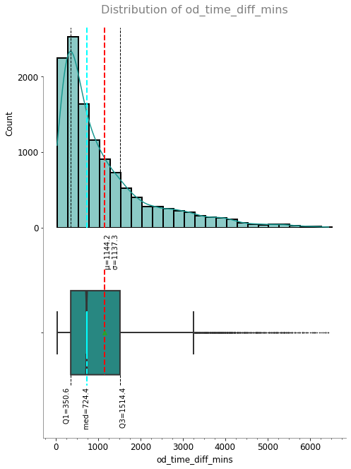

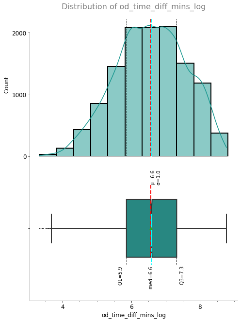

```python
plot_numeric_distribution(df, 'od_time_diff_mins', 'Tittle_', 'xlablel_', 'title_', box_major=1000, box_minor=250)
df['od_time_diff_mins_log'] = np.log(df['od_time_diff_mins'])
plot_numeric_distribution(df, 'od_time_diff_mins_log', 'Tittle_', 'xlablel_', 'title_', box_major=2, box_minor=0.5)
```

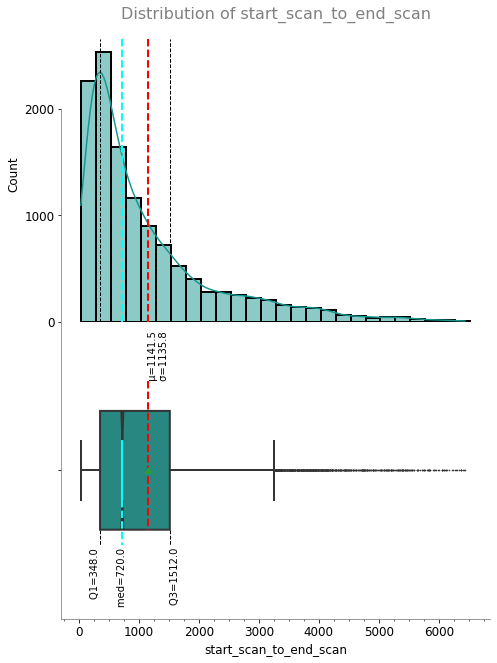

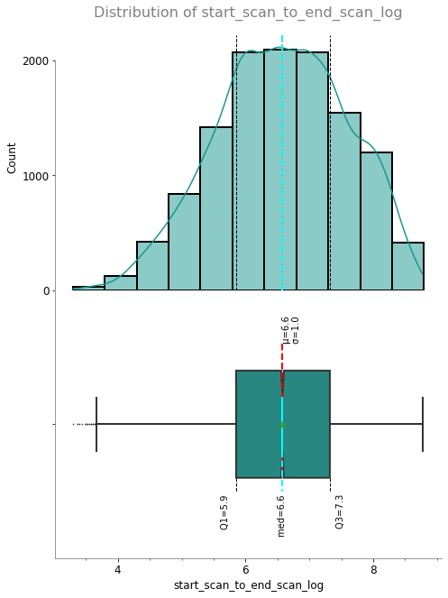

```python
plot_numeric_distribution(df, 'start_scan_to_end_scan', 'Tittle_', 'xlablel_', 'title_', box_major=1000, box_minor=250)
df['start_scan_to_end_scan_log'] = np.log(df['start_scan_to_end_scan'])
plot_numeric_distribution(df, 'start_scan_to_end_scan_log', 'Tittle_', 'xlablel_', 'title_', box_major=2, box_minor=0.5)
```

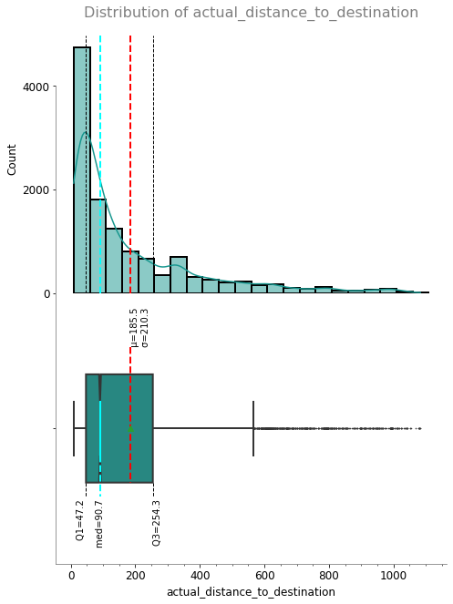

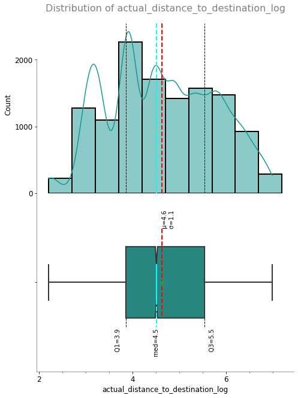

```python
plot_numeric_distribution(df, 'actual_distance_to_destination', 'Tittle_', 'xlablel_', 'title_', box_major=200, box_minor=50)
df['actual_distance_to_destination_log'] = np.log(df['actual_distance_to_destination'])
plot_numeric_distribution(df, 'actual_distance_to_destination_log', 'Tittle_', 'xlablel_', 'title_', box_major=2, box_minor=0.5)
```

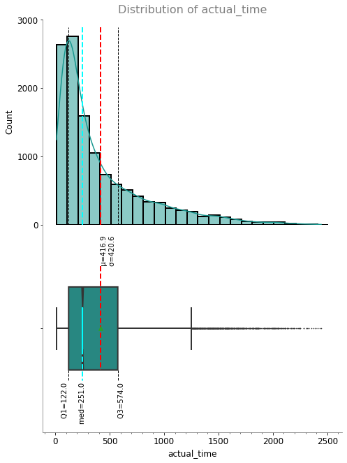

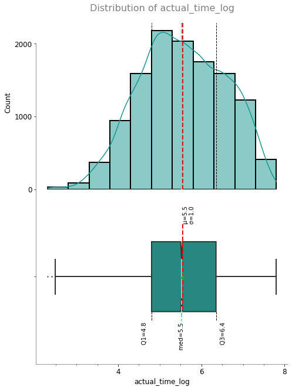

```python
plot_numeric_distribution(df, 'actual_time', 'Tittle_', 'xlablel_', 'title_', box_major=500, box_minor=100)
df['actual_time_log'] = np.log(df['actual_time'])
plot_numeric_distribution(df, 'actual_time_log', 'Tittle_', 'xlablel_', 'title_', box_major=2, box_minor=0.5)
```

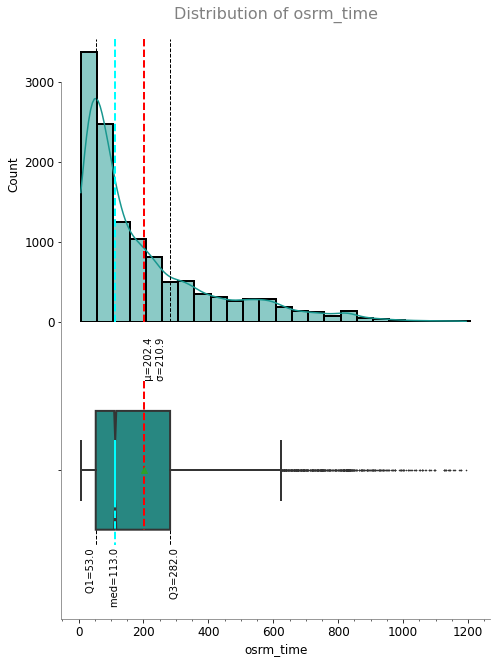

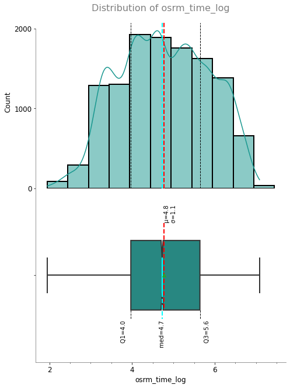

```python
plot_numeric_distribution(df, 'osrm_time', 'Tittle_', 'xlablel_', 'title_', box_major=200, box_minor=50)
df['osrm_time_log'] = np.log(df['osrm_time'])
plot_numeric_distribution(df, 'osrm_time_log', 'Tittle_', 'xlablel_', 'title_', box_major=2, box_minor=0.5)
```

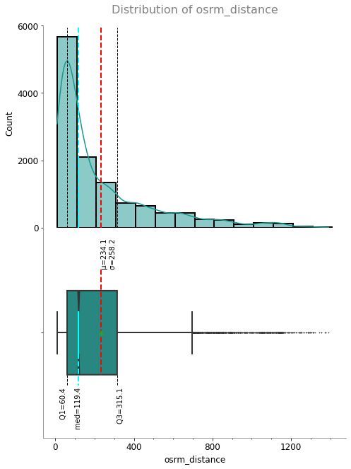

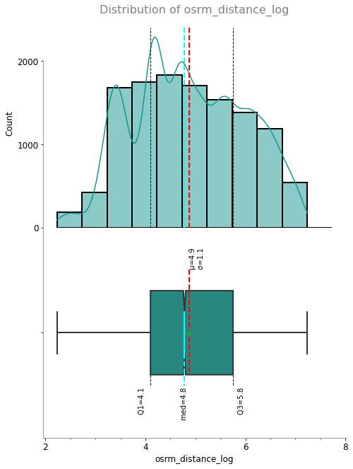

```python
plot_numeric_distribution(df, 'osrm_distance', 'Tittle_', 'xlablel_', 'title_', box_major=400, box_minor=100)
df['osrm_distance_log'] = np.log(df['osrm_distance'])
plot_numeric_distribution(df, 'osrm_distance_log', 'Tittle_', 'xlablel_', 'title_', box_major=2, box_minor=0.5)
```

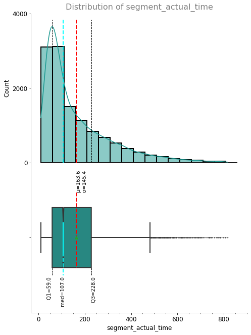

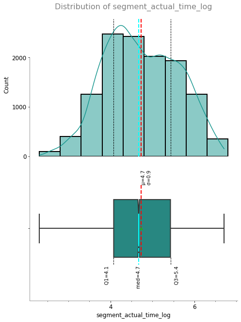

```python
plot_numeric_distribution(df, 'segment_actual_time', 'Tittle_', 'xlablel_', 'title_', box_major=200, box_minor=50)
df['segment_actual_time_log'] = np.log(df['segment_actual_time'])
plot_numeric_distribution(df, 'segment_actual_time_log', 'Tittle_', 'xlablel_', 'title_', box_major=2, box_minor=0.5)
```

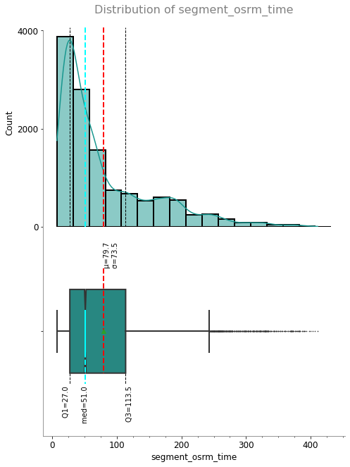

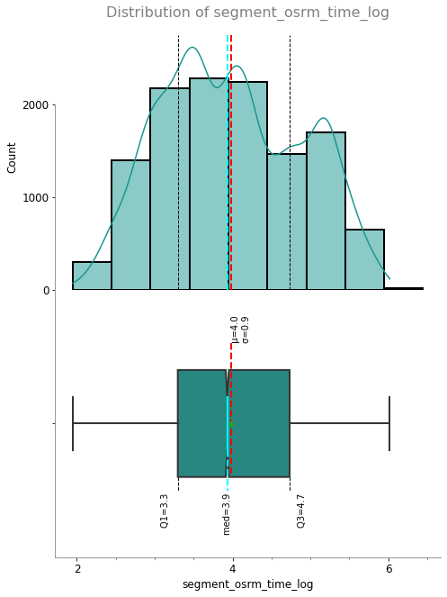

```python
plot_numeric_distribution(df, 'segment_osrm_time', 'Tittle_', 'xlablel_', 'title_', box_major=100, box_minor=25)
df['segment_osrm_time_log'] = np.log(df['segment_osrm_time'])
plot_numeric_distribution(df, 'segment_osrm_time_log', 'Tittle_', 'xlablel_', 'title_', box_major=2, box_minor=0.5)
```

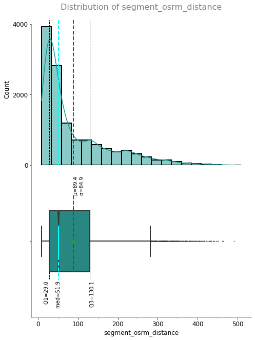

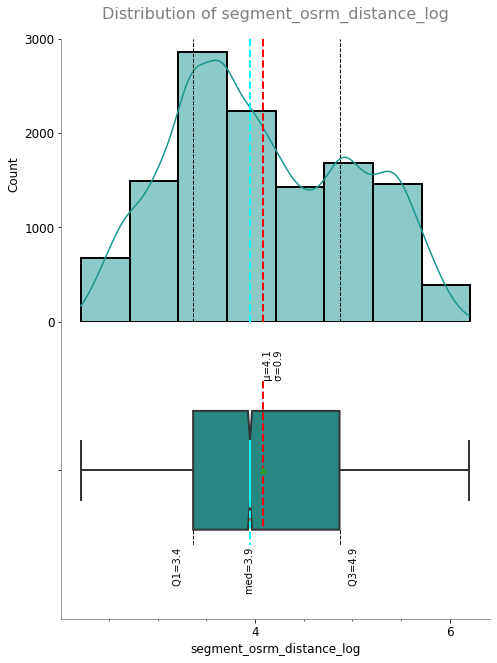

```python
plot_numeric_distribution(df, 'segment_osrm_distance', 'Tittle_', 'xlablel_', 'title_', box_major=100, box_minor=25)
df['segment_osrm_distance_log'] = np.log(df['segment_osrm_distance'])
plot_numeric_distribution(df, 'segment_osrm_distance_log', 'Tittle_', 'xlablel_', 'title_', box_major=2, box_minor=0.5)
```

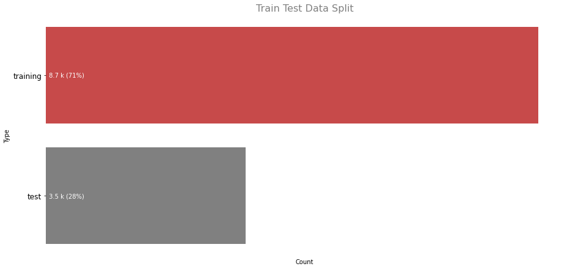

```python
plt_most10_count_plot(plt.subplot(), df, '', 'data', '', 'Train Test Data Split', 'Type', 'Count', unit_='', highlight_num=1, highlight_color='#DC3535', orientation_='h', agg_func='Count', agg_var=None).show()
```

Comparison & Visualization of time and distance fields

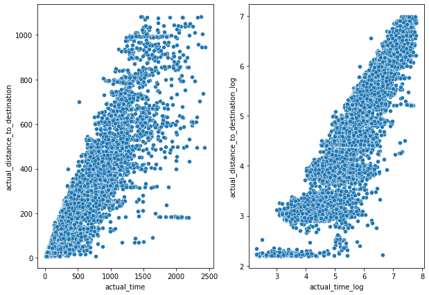

```python
fig, ax = plt.subplots(1, 2, figsize=(10, 7))
sns.scatterplot(data = df, x = 'actual_time', y = 'actual_distance_to_destination', ax=ax[0])
sns.scatterplot(data = df, x = 'actual_time_log', y = 'actual_distance_to_destination_log', ax=ax[1])
plt.show()
```

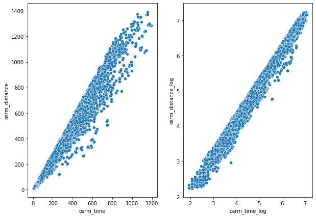

```python
fig, ax = plt.subplots(1, 2, figsize=(10, 7))
sns.scatterplot(data = df, x = 'osrm_time', y = 'osrm_distance', ax=ax[0])
sns.scatterplot(data = df, x = 'osrm_time_log', y = 'osrm_distance_log', ax=ax[1])
plt.show()
```

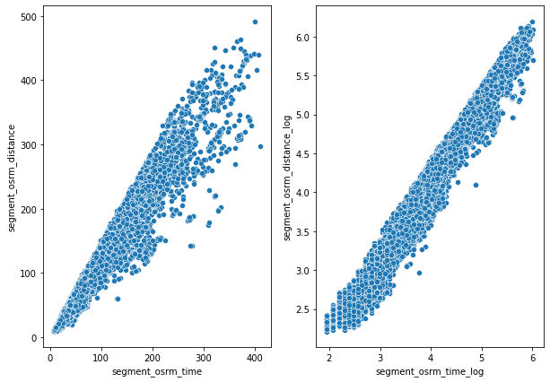

```python
fig, ax = plt.subplots(1, 2, figsize=(10, 7))
sns.scatterplot(data = df, x = 'segment_osrm_time', y = 'segment_osrm_distance', ax=ax[0])
sns.scatterplot(data = df, x = 'segment_osrm_time_log', y = 'segment_osrm_distance_log', ax=ax[1])
plt.show()
```

## Hypothesis Testing

Assume Significance Level ($\alpha$) as 0.05.

All the numeric features visually appear to be log normally distributed. We can assume, above features are log normally distributed.

Log normal scatter plots look to have equal variances.

**Test 1**

H0 = Mean of od_time_diff_mins and start_scan_to_end_scan are not significantly different

Ha = Mean of od_time_diff_mins and start_scan_to_end_scan are significantly different

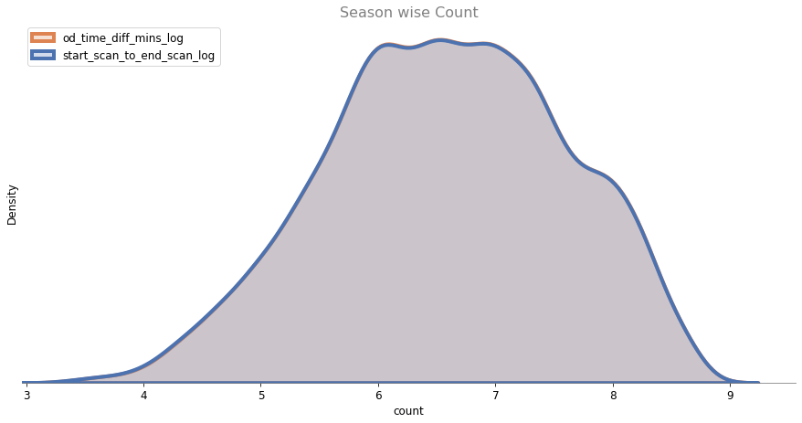

```python
df_dist = pd.DataFrame({
    'Type' : np.repeat(['od_time_diff_mins_log', 'start_scan_to_end_scan_log'], [len(df['od_time_diff_mins_log']), len(df['start_scan_to_end_scan_log'])]),
    'Values' : pd.concat((df['od_time_diff_mins_log'], df['start_scan_to_end_scan_log']))
})
plot_kde_distribution(plt.subplot(), df_dist, 'Type', 'Values', 'Season wise Count', 'count', 'Density').show()
```

Visullay both the distribution look identical.

```python
stats.levene(df['od_time_diff_mins_log'], df['start_scan_to_end_scan_log'])
```

```
LeveneResult(statistic=0.03117851384397478, pvalue=0.859844178127743)
```

Since p_value > significance level; we can assume equal variances

```python
stats.ttest_ind(df['od_time_diff_mins_log'], df['start_scan_to_end_scan_log'])
```

```
Ttest_indResult(statistic=0.282703024175061, pvalue=0.777406892326873)
```

**Test 2**

H0 = Mean of actual_time and osrm_time are not significantly different

Ha = Mean of actual_time and osrm_time are significantly different

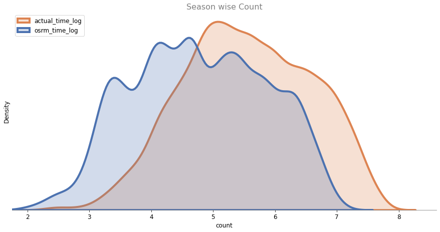

```python
df_dist = pd.DataFrame({
    'Type' : np.repeat(['actual_time_log', 'osrm_time_log'], [len(df['actual_time_log']), len(df['osrm_time_log'])]),
    'Values' : pd.concat((df['actual_time_log'], df['osrm_time_log']))
})
plot_kde_distribution(plt.subplot(), df_dist, 'Type', 'Values', 'Season wise Count', 'count', 'Density').show()
```

Visullay both the distribution look different.

```python
stats.levene(df['actual_time_log'], df['osrm_time_log'])
```

```
LeveneResult(statistic=58.45681797951643, pvalue=2.154389317124431e-14)
```

Since p_value < significance level; we can assume variances are significantly different

We chose to perform non-parametric test

```python
stats.kstest(df['actual_time'], df['osrm_time'])
```

```
KstestResult(statistic=0.27760045830264346, pvalue=0.0)
```

Since p_value < significance level; mean of actual_time and osrm_time are significantly different.

**Test 3**

H0 = Mean of actual_time and segment_actual_time are not significantly different

Ha = Mean of actual_time and segment_actual_time are significantly different

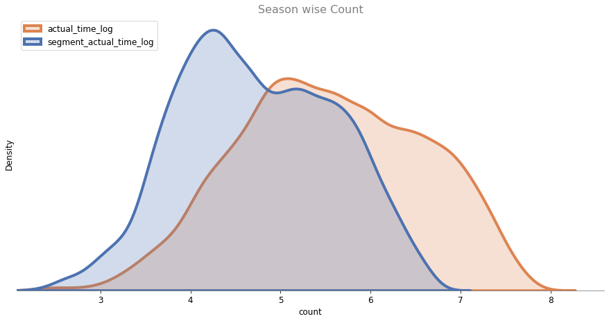

```python
df_dist = pd.DataFrame({
    'Type' : np.repeat(['actual_time_log', 'segment_actual_time_log'], [len(df['actual_time_log']), len(df['segment_actual_time_log'])]),
    'Values' : pd.concat((df['actual_time_log'], df['segment_actual_time_log']))
})
plot_kde_distribution(plt.subplot(), df_dist, 'Type', 'Values', 'Season wise Count', 'count', 'Density').show()
```

Visullay both the distribution look different.

```python
stats.levene(df['actual_time_log'], df['segment_actual_time_log'])
```

```
LeveneResult(statistic=339.61604946884137, pvalue=2.507577595431446e-75)
```

Since p_value < significance level; we can assume variances are significantly different

We chose to perform non-parametric test

```python
stats.kstest(df['actual_time'], df['segment_actual_time'])
```

```
KstestResult(statistic=0.29887879531876593, pvalue=0.0)
```

Since p_value < significance level; mean of actual_time and segment_actual_time are significantly different

**Test 4**

H0 = Mean of osrm_distance and segment_osrm_distance are not significantly different

Ha = Mean of osrm_distance and segment_osrm_distance are significantly different

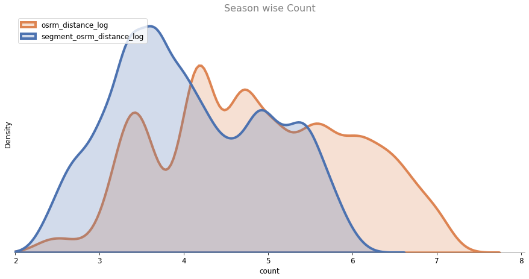

```python
df_dist = pd.DataFrame({
    'Type' : np.repeat(['osrm_distance_log', 'segment_osrm_distance_log'], [len(df['osrm_distance_log']), len(df['segment_osrm_distance_log'])]),
    'Values' : pd.concat((df['osrm_distance_log'], df['segment_osrm_distance_log']))
})
plot_kde_distribution(plt.subplot(), df_dist, 'Type', 'Values', 'Season wise Count', 'count', 'Density').show()
```

Visullay both the distribution look different.

```python
stats.levene(df['osrm_distance_log'], df['segment_osrm_distance_log'])
```

```
LeveneResult(statistic=521.0798471630106, pvalue=3.852435304124549e-114)
```

Since p_value < significance level; we can assume variances are significantly different

We chose to perform non-parametric test

```python
stats.kstest(df['osrm_distance_log'], df['segment_osrm_distance_log'])
```

```
KstestResult(statistic=0.31598330468941815, pvalue=0.0)
```

Since p_value < significance level; mean of osrm_distance and segment_osrm_distance are significantly different

**Test 5**